# Kvantitativ indholdsanalyse og ‘big data’

Metode 1 F25 #13

Søren Damsbo-Svendsen

14. maj 2025

## Temaer

- Kvantitativ indholdsanalyse
- ‘Big data’

## Hovedpointer

- **Kvantitativ indholdsanalyse** handler om at skabe struktur i et råt (ustruktureret) datamateriale
  - indebærer *kodning* af datamaterialet (ofte tekster) på centrale dimensioner
  - *kodning* = tilskrivning af værdier/kategorier, klassificering
- Der findes fire (vidt) forskellige kodestrategier med forskellige styrker/svagheder
- **Big data** er en samlebetegnelse for nye digitale *datakilder* og *sofistikerede modeller* til databehandling, kodning og analyse
  - stort overlap mellem de to temaer

## Plan for forelæsningen

1. *Recap:* eksperimenter
2. Kvantitativ indholdsanalyse
   - bibelsk analogi
   - formål og vigtige koncepter
   - 4 typer
   - eksempler
3. Text-as-data
4. Big data
5. Opsamling

## *Recap:* eksperimenter

- Eksperimenter er guldstandarden for *kausal inferens*
- **Essensen:** gennem *tilfældig inddeling* i to (eller flere) grupper, sikrer vi, at grupperne statistisk set er identiske
  - → ingen confounding
  - → vi forventer samme **outcome** som udgangspunkt (de er ens!)
  - men vi giver et **treatment** til den ene gruppe
  - forskellen på gruppernes *outcome* MÅ tilskrives treatment (eneste forskel!)
  - forskellen = den kausale effekt – *average treatment effect (ATE)*
- *Antagelserne* er simple: (1) *randomisering*, (2) *ekskluderbarhed*, (3) *fravær af interferens*
- *Ulemperne* har især at gøre med *ekstern/økologisk validitet*

# Kvantitativ indholdsanalyse og big data

## Hvorfor blev Jesus født i Bethlehem?

> *Og det skete i de dage, at der udgik en befaling fra kejser Augustus om at holde folketælling i hele verden. Det var den første folketælling, mens Kvirinius var statholder i Syrien. Og alle drog hen for at lade sig indskrive, hver til sin by. Også Josef drog op fra byen Nazaret i Galilæa til Judæa, til Davids by, som hedder Betlehem, fordi han var af Davids hus og slægt, for at lade sig indskrive sammen med Maria, sin forlovede, som ventede et barn.*

> Lukasevangeliet kap. 2, vers 1-14

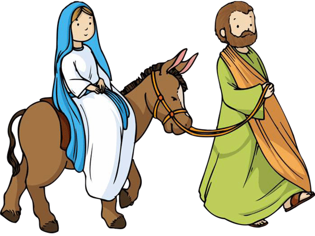

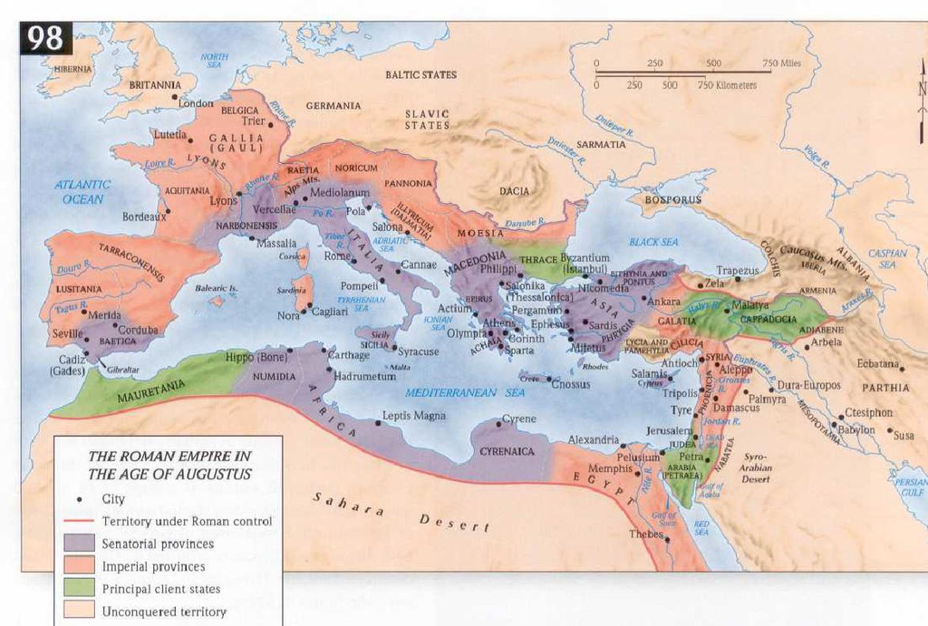

[figure not shown]

## Fordi romerne havde brug for strukturerede data!

- Det romerske imperium gennemførte regelmæssigt **folketællinger** af hensyn til beskatning, militær værnepligt og administrative formål
  - alle indbyggere i Judea blev pålagt at tage til byen, deres slægtslinje stammede fra, og oplyse *husstandens navne, ejendomsejerskab, alder, beskæftigelse osv.*
  - *data* blev *dokumenteret* af embedsmænd og senere *analyseret* mhp. at fastslå *skattemæssige og militære forpligtelser* osv.
- **Kvantitativ indholdsanalyse**, ‘big data’ og den **romerske folketælling** deler samme mål:
  - → rensede, valide, strukturerede data
  - der ikke eksisterede (i den form) tidligere
  - kan bruges til mange typer analyser
  - (ok, romernes data havde ultimativt et rent *politisk* formål, mens vores formål er mere nobelt og *videnskabeligt*)

## Moderne eksempel: ‘the Manifesto Project’

- I 1979 besluttede en gruppe forskere at indsamle og kode parti-/valgprogrammer i forbindelse med den demokratiske verdens valg
  - projektet kører stadig under navnet [‘the Manifesto Project’](https://manifesto-project.wzb.eu/)
- Normalt er parti-/valgprogrammer et stykke *politisk kommunikation* (tekst!) rettet indad mod partiet selv – og udad mod potentielle vælgere
- Forskerne havde behov for *strukturerede data* for at kunne belyse og sammenligne partiernes (proklamerede) politik over tid
  - bl.a. *ideologi / venstre-højre-placering* (utallige anvendelsesmuligheder)
- De indsamlede *alle* partiprogrammer og fik eksperter til *manuelt* at kode indholdet (politiske prioriteringer) ud fra en **kodebog**
- I 2009 havde de indsamlet og kodet 3000 programmer fra 780 partier, 525 valg, 50 lande (1945-2009)
- Samme formål som den romerske folketælling i år 0 ([sådan ca.](https://ing.dk/artikel/kunne-kejser-augustus-virkelig-skrive-al-verden-i-mandtal)) …

## Moderne eksempel: ‘the Manifesto Project’

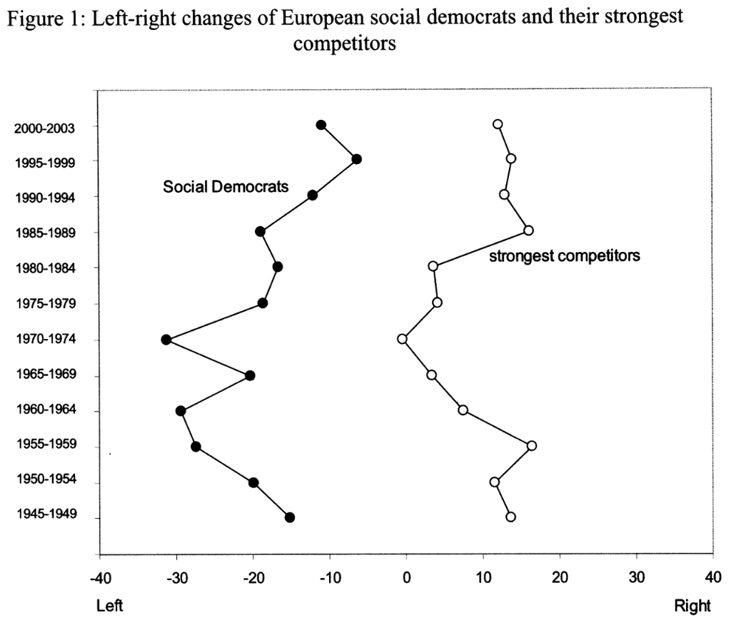

Volkens et al. (2009)

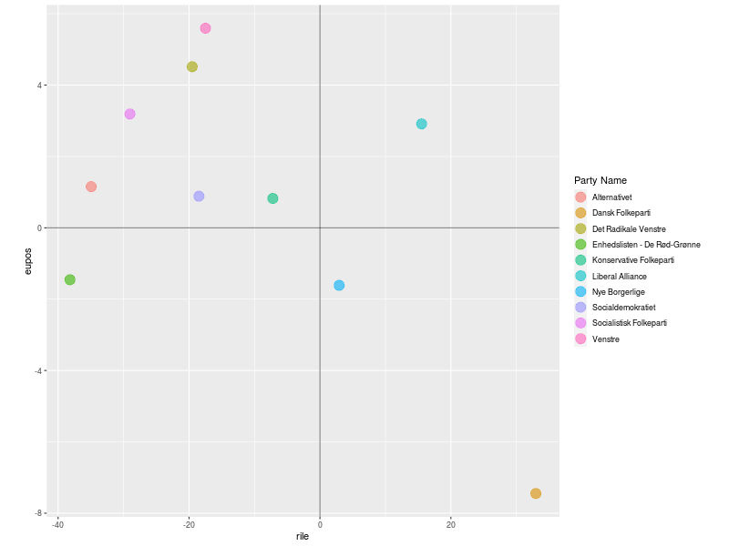

Positiv over for EU-integration (Y) vs. venstre-højre-placering (X), FV2019

## Kvantitativ indholdsanalyse

- Handler om at anskaffe, skabe og strukturere (tekst)data
  - meningsfulde kategorier, værdier osv., der indkapsler elementer af materialets mening
  - en måde at skabe viden og stor forskningsmæssig værdi gennem dataskabelse
- Et råt, ubehandlet datamateriale (fx en samling tekster) forberedes til senere analyse
- *Analysen* kan være triviel
  - med nye data er enkle analyser ofte meget værdifulde
  - gennemsnit, fordeling, udvikling over tid, bivariat sammenligning osv.
- Analysen kan også være avanceret
  - de nye data kan indgå i andre model- eller designbaserede metoder
  - og de kan klassificeres/analyseres vha. statistiske (tekst)modeller

## Datakilder

- Nyheder (Infomedia, nyhedssites, traditionelle medier)
- Blogs, sociale medier (APIer, hjemmesider, andenhånds)
- Parlamentariske dokumenter, taler og love (fx ft.dk, retsinformation.dk, ParlSpeech, …)
- Parti- og regeringsprogrammer
- Prækodede datasæt (fx Comparative Agenda Project, Manifesto Project, Comparative Campaign Dynamics Dataset)
- Pressemeddelelser
- Digitaliserede bøger mv.
- Databaser og platforme med andre medier (video, billeder)
- Transkriberede taler/videoer
- Kun fantasien sætter grænser (‘*indhold*’)

## Fire kodestrategier

Kodestrategier (MIS Tabel 21.1)

| Strategi | Operationalisering | Kodning |
| --- | --- | --- |
| Manuel | Manuel | Manuel |
| Automatisk (ordbog) | Manuel | Automatisk |
| Automatisk (superviseret model) | Manuel | Automatisk |
| Automatisk (usuperviseret model) | Automatisk | Automatisk |

- *Formål:* at **klassificere** forskellige dimensioner af teksters *indhold/mening* (eller andre medier)
- Fire kvalitativt forskellige *typer*
- Også *kontinuum* af mindre—mere *hands-on* styring
- Kan kombineres og supplere hinanden

## Fire kodestrategier – fortsat

Kodestrategier (MIS Tabel 21.1) – udvidet

| Strategi | Operationalisering | Kodning | Validering | Transparens |
| --- | --- | --- | --- | --- |
| Manuel | Manuel | Manuel | Manuel | Høj (kodebog) |
| Automatisk (ordbog) | Manuel | Automatisk | Manuel | Høj (kodebog) |
| Automatisk (superviseret model) | Manuel | Automatisk | Manuel | Lav |
| Automatisk (usuperviseret model) | Automatisk | Automatisk | Manuel | Meget lav |

- **Validering** – før, undervejs og efterfølgende
  - meget vigtigt og *altid (delvist) manuelt*
- **Transparens** – vigtigt, potentielt trade-off
- **Reliabilitet** – tilfældig variation/støj/gentagelighed
  - afhænger bl.a. af *transparens*, *kompleksitet* og *manuel/automatisk kodning*
- **(Målings)validitet**
  - afhænger af den konkrete applikation → *validering*

## Eksempel – manuel kodestrategi

- Sidst så vi på eksperimentet, hvor vi tester effekterne af 5 (ud af 55) **chikanehistorier**
- Historierne varierer “naturligt” på mange dimensioner
- Vi havde behov for at systematisere dette ved at **kode teoretisk væsentlige dimensioner**
  - for at “kontrollere” for variationen
  - for at kunne analysere dimensionernes betydning
- Bemærk: sekundært for studiet, ikke den primær analyse
- Alligevel lavede vi en **kodebog →**

## Kodebog

- En kodebog er *essentiel* ved manuel kodning
  - ofte også automatisk kodning
- Sikrer at alle variable og kategorier er beskrevet grundigt
  1. så andre (og fremtidige dig) ved *hvordan data skal forstås og anvendes*
  2. så andre (og fremtidige dig) ved *hvordan de selv skal kode materialet*
     - instruktion *før* kodningsprocessen (**kodemanual**)
     - rapportering *efter* kodningsprocessen

## Kodebog

- Der er ingen væsentlige *formkrav*
  - ser ikke ud på en bestemt måde
- Men indholdskrav!
  - skal grundigt dokumentere skabelsen af datasættet
  - beskrivelser af *variable*, *kategorier* og (numeriske) *værdier* samt kriterierne for deres kodning
  - klare, tydelige instrukser
- Mere generelt handler det om **systematik** og **transparens** (vigtige elementer i forskning)
  - kodebogen er blot en operationalisering af disse mål

## Eksempel – manuel kodestrategi

| id | treatment_da | source | physical | sexual | threat | some | vandalism |
| --- | --- | --- | --- | --- | --- | --- | --- |
| 1 | Jeg har oplevet, at mine valgplakater blev "halshugget" af ukendte personer. Mine børn på syv og ni år har set det, hvilket var meget ubehageligt. | 1 | 0 | 0 | 1 | 0 | 1 |
| 2 | Jeg har oplevet, at en borger til et vælgermøde udbrød "hvis ikke du er enig med mig, trækker jeg kniven!" | 1 | 0 | 0 | 1 | 0 | 0 |
| 3 | En partifælle skrev flere gange i sms'er til vores kollegaer og mig, at mine synspunkter var "useriøse kommentarer" og "støj på linjen". | 2 | 0 | 0 | 0 | 0 | 0 |
| 4 | Tilfældige vælgere har flere gange sagt til mig, at jeg "var for tyk og burde slanke mig". | 1 | 0 | 0 | 0 | 0 | 0 |
| 5 | Ukendte personer sendte en e-mail med en falsk aflysning af en valgfestival, hvor jeg ellers skulle have deltaget som kandidat og forhåbentlig kunne have overbevist nogle vælgere om at stemme på mig. | 1 | 0 | 0 | 0 | 0 | 0 |
| 6 | Engang forsøgte en gruppe på 6-7 yngre mænd at overfalde mig på vejen hjem fra et vælgermøde. Jeg har haft talrige lignende oplevelser. | 1 | 1 | 0 | 1 | 0 | 0 |
| 7 | Der var en person, der råbte "fucking kampagneluder, jeg kommer og river alle dine plakater ned" efter mig og min frivillige hjælper, da vi var ved at hænge mine valgplakater op. | 1 | 0 | 0 | 0 | 0 | 1 |
| 8 | Jeg har prøvet, at en borger befamlede mig fysisk, og at vedkommende tydeligvis mente, det var helt i orden. | 1 | 1 | 1 | 0 | 0 | 0 |
| 9 | Jeg har gentagne gange oplevet at blive nedgjort af partikollegaer på grund af min alder. | 2 | 0 | 0 | 0 | 0 | 0 |
| 10 | Folk skriver direkte til mig på Facebook, at jeg er nazist, racist, psykopat eller et svin. | 1 | 0 | 0 | 0 | 1 | 0 |
| 11 | Jeg har oplevet ubehagelige tilnærmelser i privatbeskeder på sociale medier fra personer i alle aldre. | 1 | 0 | 0 | 0 | 1 | 0 |
| 12 | I min kommune har vi tre toppolitikere, som udviser en stor grad af magt-arrogance imod alle os nye kandidater, gamle som unge. De taler ned til os, som om vi var dumme. | 3 | 0 | 0 | 0 | 0 | 0 |
| 13 | Jeg oplever sexchikane fra vælgere, som for eksempel kommer til udtryk ved at folk helt tydeligt kigger på min krop med et "elevatorblik". | 1 | 0 | 1 | 0 | 0 | 0 |
| 14 | Jeg modtager sms'er med uønskede seksuelle spørgsmål, hvilket er meget ubehageligt, og det er fortsat gennem hele valgkampen. | 1 | 0 | 1 | 0 | 0 | 0 |
| 15 | Jeg har modtaget dødstrusler fra ukendte afsendere rettet både mod mine små brødre og mine egne børn. | 1 | 0 | 0 | 1 | 0 | 0 |
| 16 | Jeg er blevet kørt på og nedgjort gennem hele valgkampen af en medkandidat fra mit eget parti på grund af mit køn og min alder. | 2 | 0 | 0 | 0 | 0 | 0 |
| 17 | Jeg har fået at vide af en vælger, at jeg og min familie skulle udryddes, fordi jeg var en "landsforræder". | 1 | 0 | 0 | 1 | 0 | 0 |
| 18 | På et tidspunkt kom der en lang kommentar til et opslag på et socialt medie, hvor en "debattør" fra vores kommune beskriver mine påståede manglende evner. | 1 | 0 | 0 | 0 | 1 | 0 |
| 19 | En anden lokalpolitisk kandidat bad mig sætte mig ned og holde min mund, fordi jeg var "for ung og uerfaren" til at være politiker. | 3 | 0 | 0 | 0 | 0 | 0 |
| 20 | Der var en borger, som kørte rundt i bil og målte hvor højt mine – og kun mine – valgplakater var placeret fra jorden. Derefter politianmeldte han mig for de plakater, der hang for lavt. | 1 | 0 | 0 | 0 | 0 | 0 |
| 21 | Jeg har oplevet umotiverede, grove kommentarer på Facebook, såsom "lede svin, du er landsskadelig". | 1 | 0 | 0 | 0 | 1 | 0 |
| 22 | Min ægtefælle havde monteret en "streamer" på siden af hendes bil med mit billede på. Efter en indkøbstur tæt på vores hjem var hele siden af bilen overspyttet af ukendte personer. | 1 | 0 | 0 | 0 | 0 | 1 |
| 23 | Jeg har oplevet at blive befamlet og "nusset" seksuelt under en husstandsomdeling, hvor jeg var alene. | 1 | 1 | 1 | 0 | 0 | 0 |
| 24 | Jeg er blevet udsat for, at en kandidat fra et andet parti satte gang i grimme rygter om min person og mit kandidatur. | 3 | 0 | 0 | 0 | 0 | 0 |
| 25 | Der var en vælger, der skrev en kommentar til et politisk opslag på de sociale medier, om at jeg burde spærres inde på psykiatrisk afdeling. | 1 | 0 | 0 | 0 | 1 | 0 |
| 26 | Jeg får ofte at vide af vælgere, at jeg ikke burde deltage i politik, men skulle blive hjemme med mine børn. | 1 | 0 | 0 | 0 | 0 | 0 |
| 27 | Jeg er blevet overfuset flere gange af en anden kandidat fra mit eget parti i så voldsom grad, at jeg brød sammen foran en masse frivillige og tilfældigt forbipasserende. | 2 | 0 | 0 | 0 | 0 | 0 |
| 28 | En partikollega kom hjem til mig en sen aften og overfusede mig med en ubehagelig, ondsindet personlig kritik. | 2 | 0 | 0 | 0 | 0 | 0 |
| 29 | Folk, jeg ikke kender, trængte på et tidspunkt ind på min private ejendom og klippede mit store valgbanner ned, mens jeg ikke var hjemme. | 1 | 0 | 0 | 0 | 0 | 1 |
| 30 | Jeg har prøvet, at en ordstyrer til en politisk debat sagde, at man ikke skal lytte til mig på grund af mine psykiske diagnoser. | 3 | 0 | 0 | 0 | 0 | 0 |
| 31 | Jeg har oplevet gentagne forsøg på at undergrave min troværdighed og nedgøre mig fra en bestemt persongruppe i mit parti. | 2 | 0 | 0 | 0 | 0 | 0 |
| 32 | "Hitler-symboler" på flere af mine valgplakater gjorde virkelig et ubehageligt indtryk. | 1 | 0 | 0 | 0 | 0 | 1 |
| 33 | Jeg har prøvet at blive truet på mit job, hvor jeg laver myndighedsarbejde. Jeg blev truet med, at det ikke ville gå godt med min valgkamp, hvis jeg gav personen afslag på en bevilling. | 1 | 0 | 0 | 0 | 0 | 0 |
| 34 | En uhyggelig person kom hen helt tæt på mig og sagde, at han burde spytte på partilogoet på min jakke. | 1 | 1 | 0 | 1 | 0 | 0 |
| 35 | Et byrådsmedlem fra et andet parti skrev dårlige ting om mig til alle i mit parti og kørte en personlig hetz mod mig på sociale medier på grund af en kommentar, jeg havde skrevet derinde. | 3 | 0 | 0 | 0 | 1 | 0 |
| 36 | Jeg har prøvet at blive afbrudt og grinet af/mobbet af andre lokalpolitikere midt i en debat, fordi jeg som ordblind udtalte et ord forkert. | 3 | 0 | 0 | 0 | 0 | 0 |
| 37 | Jeg er blevet truet af en fremmed, der vidste, hvor min søn gik i skole og ville finde ham og derefter opsøge mig. | 1 | 0 | 0 | 1 | 0 | 0 |
| 38 | Jeg er blevet overfuset af en stor mand, mens jeg uddelte flyers ved en togstation. Jeg var bange for, at han ville blive voldelig. | 1 | 1 | 0 | 1 | 0 | 0 |
| 39 | Jeg er blevet stalket gennem mere end et halvt år af en fremmed person, hvilket endte med at udløse et femårigt polititilhold. | 1 | 0 | 0 | 1 | 0 | 0 |
| 40 | Jeg har oplevet, at min politikerside på Facebook blev delt af en falsk profil med en opfordring om at kommentere negativt på alle mine opslag. | 1 | 0 | 0 | 0 | 1 | 0 |
| 41 | Flere medlemmer af partierne på den modsatte fløj omtalte mig konsekvent som "kakerlakken", både til borgerne og internt i deres partier. | 3 | 0 | 0 | 0 | 0 | 0 |
| 42 | Jeg har oplevet, at folk på gaden foran massevis af mennesker råber ting som "din luderidiot, du er så snotdum at høre på, du skal kraftedeme bare lukke røven, din lille lort". | 1 | 0 | 0 | 0 | 0 | 0 |
| 43 | Jeg modtog systematiske telefonopkald fra, hvad der viste sig at være en gruppe unge, som kollektivt havde besluttet sig for at genere mig. Det stoppede først efter at politi og forældre blev inddrage… | 1 | 0 | 0 | 0 | 0 | 0 |
| 44 | Når jeg klarer mig godt i en politisk debat, får jeg straks at vide af de andre kandidater – også af dem fra mit eget parti – at det ikke ville være gået lige så godt, hvis jeg ikke havde det køn, jeg… | 2 | 0 | 0 | 0 | 0 | 0 |
| 45 | Jeg har fået et uønsket kys på kinden sammen med en kommentar, om at personen aldrig ville stemme på mig. | 1 | 1 | 1 | 0 | 0 | 0 |
| 46 | Mens jeg stod på åben gade og talte med min niece på fire år, blev jeg tilsvinet af en forbipasserende. | 1 | 0 | 0 | 0 | 0 | 0 |
| 47 | Folk ødelægger eller river mine valgplakater ned, og det hidser mig op, fordi det er så stort et arbejde at sætte dem op på de rigtige placeringer. | 1 | 0 | 0 | 0 | 0 | 1 |
| 48 | Der var en person, der sagde til mig, at min familie og jeg "skulle en tur i et gaskammer". | 1 | 0 | 0 | 1 | 0 | 0 |
| 49 | Ukendte personer stak ild til et af mine bannere med mit billede på. | 1 | 0 | 0 | 1 | 0 | 1 |
| 50 | Jeg fik at vide af en vælger, at vedkommende kun ville stemme på mig, hvis de måtte bruge det kondom, som jeg havde uddelt i min valgkampagne, sammen med mig. | 1 | 0 | 1 | 1 | 0 | 0 |
| 51 | Jeg har oplevet at komme hjem til at flere af grantræerne i min forhave var blevet savet ned. | 1 | 0 | 0 | 0 | 0 | 1 |
| 52 | Folk involverer nogle gange min familie i deres kritik af mig. De skriver for eksempel, at både min ægtefælle og jeg er korrupte, eller at jeg ødelægger mine børns fremtid. | 1 | 0 | 0 | 0 | 0 | 0 |
| 53 | Der var en, der sparkede et flag med mit billede på ned, som vi havde sat op på den togstation, hvor vi lavede kampagne. Personen trådte på flaget og råbte af mine frivillige. | 1 | 1 | 0 | 1 | 0 | 1 |
| 54 | Jeg har oplevet, at en person skrev nedladende skældsord om mig på min politikerside på Facebook og også sendte dem rundt til de andre kandidater. | 1 | 0 | 0 | 0 | 1 | 0 |
| 55 | Efter valget havde jeg en ubehagelig oplevelse med et medlem fra et andet parti, som, uden mit samtykke, havde taget et billede af mig og lagt det op på Facebook. | 1 | 0 | 0 | 0 | 1 | 0 |

## Eksempel – manuel kodestrategi

| variabelnavn | beskrivelse af variabel | kode | beskrivelse af kode |
| --- | --- | --- | --- |
| køn | politikerens køn | m | mand |
| køn | politikerens køn | k | kvinde |
| alder | politikerens alder i år | 18-99 | - |
| erfaring | politikerens erfaring i politik | -1 | har aldrig stillet op tidligere |
| erfaring | politikerens erfaring i politik | 0 | har stillet op tidligere, men aldrig vundet |
| erfaring | politikerens erfaring i politik | 1 | er tidligere blevet valgt |
| venstrefløj | politikerens parti | 1 | et venstrefløjsparti (S, SF, Ø, Å, RV) |
| venstrefløj | politikerens parti | 0 | et højrefløjsparti (V, KF, DF, NB, LA) |
| afsender | afsenderen/gerningspersonen i historien | 1 | en borger, ukendt person, vælger (udenfor det politiske system) |
| afsender | afsenderen/gerningspersonen i historien | 2 | en partikollega |
| afsender | afsenderen/gerningspersonen i historien | 3 | politiker fra et andet parti, journalist, ordstyrer (inden for det politiske system) |
| fysisk | historien vedrører fysisk chikane | 1 | ja (fysisk berøring, vold, intimiderende nærhed) |
| fysisk | historien vedrører fysisk chikane | 0 | nej |
| seksuel | historien vedrører seksuel chikane | 1 | ja (fysisk berøring med seksuelle undertoner, seksuelle temaer) |
| seksuel | historien vedrører seksuel chikane | 0 | nej |
| trussel | historien indeholder en trussel om fysisk vold | 1 | ja (intimiderende nærhed, verbale trusler, symbolske trusler fx vold mod plakat/billede) |
| trussel | historien indeholder en trussel om fysisk vold | 0 | nej (ingen trussel, materialiseret fysisk vold) |
| some | historiens hovedarena er de sociale medier | 1 | ja (ord, billeder, kommentarer, opslag, deling på sociale medier fx Facebook) |
| some | historiens hovedarena er de sociale medier | 0 | nej |
| hærvæk | historien indeholder hærværk mod politikerens ejendele eller symboler | 1 | ja (ødelæggelse af valgplakater, bannere, flag, privat ejendom) |
| hærvæk | historien indeholder hærværk mod politikerens ejendele eller symboler | 0 | nej |
| historie_rev | den redigerede historie | tekst | - |
| historie_orig | den oprindelige, uredigerede historie (evt. uddrag) | tekst | - |

## Automatisk kodestrategi (ordbog)

- Grundlæggende princip:
  - definér nogle **nøgleord**, som – hvis de er tilstede (eksplicit) – udløser en bestemt kode (værdi, kategori)
  - fx “klimaforandringer” → *klima = 1*
  - fx “Danmarksdemokraterne” → *partipolitik = 1*
- “Ordbog” af nøgleord (input) og koder (output)
- Der findes mange etablerede ordboger
  - fx [AFINN](https://github.com/fnielsen/afinn/blob/master/afinn/data/AFINN-da-32.txt) til *sentiment*-analyse
- Kan fx implementeres i R gennem en simpel ‘søgning’ på nøgleordene med {stringr}-pakken (Hadley Wickham, ofc)

## Eksempel: mediedækning (saliens) af *klima* i 2019

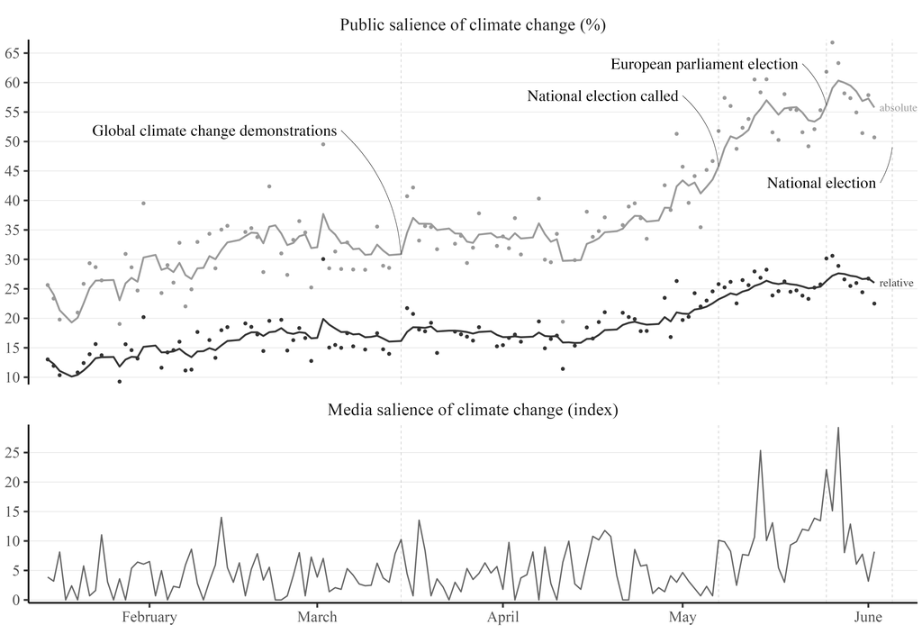

> *“I computer-code the news articles using **dictionary-based quantitative content analysis** with a **focused measure of climate news** that includes explicit mentions of **climate, global warming, carbon dioxide, greenhouse gas, and greenhouse effect** (cf. Carmichael & Brulle, 2017). This measure **maximizes precision** (ability to avoid irrelevant articles) whereas **recall** (ability to retrieve relevant articles) may be less than perfect”*

> (Damsbo-Svendsen 2022)

## R: stringr og regex<sup>1</sup>

- {stringr}-pakken er uundværlig til basal manipulation af tekst i R (‘strings’)
  - `str_detect(tekst_var, "vindmølle")`: *tjekker* om tekstbiden, der søges efter, er til stede (*logical*)
  - `str_count(tekst_var, "vindmølle")`: *tæller* antallet af matches med tekstbiden, der søges efter (*integer*)
  - `str_extract(tekst_var, "vindmølle")`: *udtrækker* selve tekstbiden, der søges efter (*character*)
[^1]: {stringr}-cheatsheet: https://raw.githubusercontent.com/rstudio/cheatsheets/main/strings.pdf. Se også https://stringr.tidyverse.org/articles/regular-expressions.html om *regex* med {stringr}.

## R: stringr og regex<sup>1</sup>

- Tekstbiderne er reelt **regex** (*regular expressions*):
  - sekvenser af tegn, der definerer et søgemønster, som bruges til at finde, matche eller manipulere tekstdata
  - gør det muligt at søge efter komplekse mønstre i tekststrenge
  - kan være ekstremt nyttige
- Eksempler:
  - “statsminister|udenrigsminister” – A *eller* (|) B
  - “\bklima” – ordgrænse (start/slut på ord) efterfulgt af ‘klima’
  - “[a-zA-Z]{1,4}” – 1-4 bogstaver (tegn mellem a-z/A-Z)
- Masser af online *tools* og hjælp til regex, fx https://rubular.com/
[^2]: {stringr}-cheatsheet: https://raw.githubusercontent.com/rstudio/cheatsheets/main/strings.pdf. Se også https://stringr.tidyverse.org/articles/regular-expressions.html om *regex* med {stringr}.

## R: stringr og regex

```r
library(stringr)

eksempeltekst <- "- Dansk økonomi har udviklet sig bemærkelsesværdigt godt i de seneste år.
Det skriver Finansministeriet i en pressemeddelelse og varsler samtidig endnu en opjustering
af det økonomiske råderum i slutningen af juni. - Det er endnu for tidligt at sige,
hvor meget råderummet frem mod 2030 bliver opjusteret, men det forventes at resultere
i en betydelig opjustering, siger finansminister Nicolai Wammen (S)."
# kilde: www.dr.dk/nyheder/seneste/finansministeriet-varsler-betydelig-opjustering-af-raaderummet

# store bogstaver til små bogstaver
eksempeltekst_lower <- tolower(eksempeltekst)
```

```r
# enten/eller
str_detect(eksempeltekst_lower, "finansminister|råderummet")
```

```
[1] TRUE
```

```r
# tæl
str_count(eksempeltekst_lower, "finansminister|råderummet")
```

```
[1] 3
```

```r
# udtræk
str_extract_all(eksempeltekst_lower, "finansminister[a-z]*|råderummet")
```

```
[[1]]
[1] "finansministeriet" "råderummet"        "finansminister"
```

## Eksempel: folketingsdebat om klima og stormflod

**Kode**

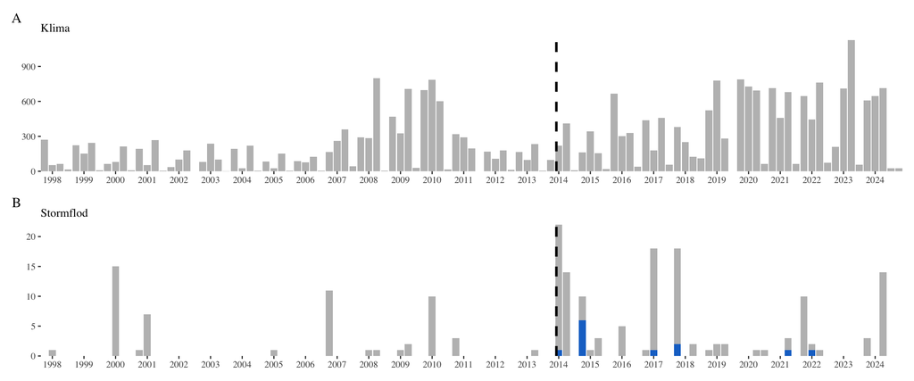

Indlæg fra FTs talerstol om klimaforandringer og stormflod (automatisk kodning med ordbogslogik)

```r
# parl_klima <- read_rds(here::here("Data", "paradf-v2.rds")) |>
#   mutate(date = ymd(str_sub(parid, 1, 10)),
#          climate = str_detect(tolower(text),
#                               "klima|global opvarmning|globale opvarmning|co2|drivhusgas|drivhuseffekt|havniveau"),
#          stormsurge = str_detect(tolower(text), "stormflod") &
#            str_detect(tolower(text), "\\bkyst|oversvøm|\\bvandstand|forsikring|stormrådet"),
#          bodil = str_detect(text, "Bodil|Roskilde Fjord|Jyllinge")) |>
#   filter(climate | stormsurge | bodil)
#
# write_rds(parl_klima, "Data/parl_klima.rds")

parl_klima <- read_rds("Data/parl_klima.rds")

p_klima <- parl_klima |>
  filter(climate) |>
  count(date) |>
  complete(date = seq.Date(min(parl_klima$date), max(parl_klima$date), 1),
           fill = list(n = 0)) |>
  group_by(period = floor_date(date, "3 months")) |>
  summarise(n = sum(n), .groups = "drop") |>
  ggplot() +
  aes(x = period, y = n) +
  geom_col(fill = "grey") +
  geom_vline(aes(xintercept = ymd("2013-12-05")), linetype = "dashed", linewidth = 1.1, show.legend = FALSE) +
  scale_x_date(date_breaks = "year", date_labels = "%Y", expand = c(0,0)) +
  scale_y_continuous(expand = c(0,0)) +
  labs(x = NULL, y = NULL, subtitle = "Klima") +
  ggthemes::theme_tufte() +
  guides(fill = "none")

p_stormflod <- parl_klima |>
  filter(stormsurge) |>
  count(bodil, date) |>
  complete(date = seq.Date(min(parl_klima$date), max(parl_klima$date), 1),
           fill = list(n = 0)) |>
  group_by(bodil, period = floor_date(date, "3 months")) |>
  summarise(n = sum(n), .groups = "drop") |>
  ggplot() +
  aes(x = period, y = n, fill = bodil) +
  geom_col() +
  geom_vline(aes(xintercept = ymd("2013-12-05")), linetype = "dashed", linewidth = 1.1, show.legend = FALSE) +
  scale_x_date(date_breaks = "year", date_labels = "%Y", expand = c(0,0)) +
  scale_y_continuous(expand = c(0,0)) +
  scale_fill_manual(values = c("grey", "dodgerblue3")) +
  labs(x = NULL, y = NULL, subtitle = "Stormflod") +
  ggthemes::theme_tufte() +
  guides(fill = "none")

p_klima / p_stormflod + plot_annotation(tag_levels = "A")
```

## Eksempel: klimavenlige politiske kandidater

- Til artiklen ‘*Pro-climate voting in response to local flooding*’ (Damsbo-Svendsen 2024)
  - havde jeg behov for at identificere **‘klimavenlige’ kandidater** til kommunalvalgene 2013-2017
  - havde jeg data fra deres svar på DR/Altingets **kandidattest**
  - der var et *fritekstfelt*, hvor kandidaterne kunne beskrive deres **mærkesager** med egne ord
- Jeg operationaliserede **klimavenlige kandidater** som dem, der selv vælger at tale om **klima, oversvømmelse og stormflod** i deres mærkesager
  - antager at der ikke er ‘negative mærkesager’
  - antager at det afspejler deres fokus på klimaproblematikker
  - antager at det er emner, de gerne taler om i valgkampen generelt

## Fremgangsmåde

Jeg samlede en liste (ordbog) af *klimarelaterede nøgleord* gennem en iterativ proces:

1. begyndte med et begrænset sæt af *klimanøgleord fra eksisterende forskning* og konverterede dem til en *regex*: **“|global[e]? opvarmning|co2|drivhuseffekt|drivhusgas|climate| global warming”**
2. tilføjede nøgleord specifikt relateret til *stormflod og oversvømmelse*: **“kystsikring|stormflod|oversvømme”**
3. søgte på de *mest anvendte ’bigrammer*’ (to ord) blandt alle matches og tilføjede de mest anvendte: **“fossile brænd|vedvarende energi|ren energi|alternativ[e]? energi|grøn[n]?[e]? energi|grøn[n]?[e]? løsning|grøn[n]?[e]? omstilling|grøn[n]?[e]? fremtid|grøn[n]?[e]? løsning|grøn[n]?[e]? kommun|grøn[n]?[e]? job|grøn[n]?[e]? arbejdsplads|grøn[n]?[e]? virksomhed|grøn[n]?[e]?[r]?[e]? kommun|kommunen[s]? grøn|bæredygtighed”**
4. analyserede *keywords in context* (KWIC) for at fjerne ord, der primært optrådte ifm. mostand mod den grønne omstilling (fx ‘vindmøller’)

## Validering med *keywords in context* (KWIC)

**Kode**

```r
set.seed(1234)

tokens <- parl_klima |>
  sample_n(200) |>
  corpus(docid_field = "parid", text_field = "text") |>
  tokens(remove_punct = FALSE,
         remove_symbols = FALSE,
         remove_numbers = FALSE,
         remove_url = FALSE,
         remove_separators = TRUE)

tokens |>
  kwic(pattern = "klima", window = 7) |>
  as.data.frame() |>
  select(docname, pre, keyword, post) |>
  sample_n(16) |>
  kable(col.names = c("", "", "", ""),
        escape = FALSE) |>
  kable_styling(font_size = 20)
```

| 2016-11-22-38-1 | kan medvirke til at tø det politiske | klima | en smule op , så vi kan |
| --- | --- | --- | --- |
| 2023-05-23-437-7 | der sikrer , at vi når de | klima | - og energipolitiske mål , den kærlige |
| 2018-11-22-392-3 | teknologiudvikling og vores muligheder for at håndtere | klima | - og ressourcekrisen . For den vækst |
| 2024-05-23-399-2 | samfundet lykkes med de mange formål vedrørende | klima | , miljø , naturgenopretning og en fortsat |
| 2010-09-07-595-10 | også vil investere i bedre miljø og | klima | . Vi leverer et overskud på de |
| 2022-05-10-699-2 | , det vil have , for vores | klima | og natur . Hvis man fjerner afgifterne |
| 2018-11-20-66-2 | , for det går ud over vores | klima | , og det bidrager også til luftforureningen |
| 2009-11-06-245-1 | møder op med andre krav inden for | klima | - og energidelen ved den kommende finanslovforhandling |
| 2009-05-11-112-12 | globaliseringsforhandlinger klar til at øge forskningsindsatsen på | klima | - og energiområdet . Vi har fordoblet |
| 2015-04-22-175-1 | i stand til at gennemføre sin egen | klima | - og energipolitik ? |
| 2003-03-12-306-1 | glasklart . Det har intet med hverken | klima | eller noget som helst andet at gøre |
| 2007-09-06-422-1 | et billede af , at miljø og | klima | ikke spiller nogen rolle . Det er |
| 2024-03-19-730-6 | dukket en række nye udfordringer op med | klima | , miljø og økonomi , og at |
| 2023-10-12-225-1 | jeg er lige kommet løbende ovre fra | Klima | - , Energi - og Forsyningsministeriet . |
| 2008-11-19-569-1 | år , altså i hele spørgsmålet om | klima | , som vi også havde lejlighed til |
| 2020-01-16-202-1 | i verden var en kæmpe debat om | klima | . Og der kom en erkendelse . |

## Keywords

Frekvensen af klimarelaterede keywords

| Keyword | Hits |
| --- | --- |
| \bklima | 874 |
| bæredygtighed | 344 |
| grøn[n]?[e]? omstilling | 285 |
| co2 | 245 |
| vedvarende energi | 206 |
| grøn[n]?[e]?[r]?[e]? kommun | 147 |
| grøn[n]?[e]? energi | 144 |
| grøn[n]?[e]? kommun | 126 |
| alternativ[e]? energi | 50 |
| fossil | 48 |
| oversvømme | 34 |
| grøn[n]?[e]? løsning | 31 |
| grøn[n]?[e]? løsning | 31 |
| grøn[n]?[e]? job | 29 |
| grøn[n]?[e]? arbejdsplads | 21 |
| kommunen[s]? grøn | 20 |
| kystsikring | 14 |
| global[e]? opvarmning | 13 |
| grøn[n]?[e]? virksomhed | 12 |
| grøn[n]?[e]? fremtid | 11 |
| c02 | 10 |
| ren[e]? energi | 10 |
| stormflod | 9 |
| drivhusgas | 5 |
| drivhuseffekt | 2 |
| climate | 0 |
| global warming | 0 |

## Eksempel: klimavenlige politiske kandidater – resultat

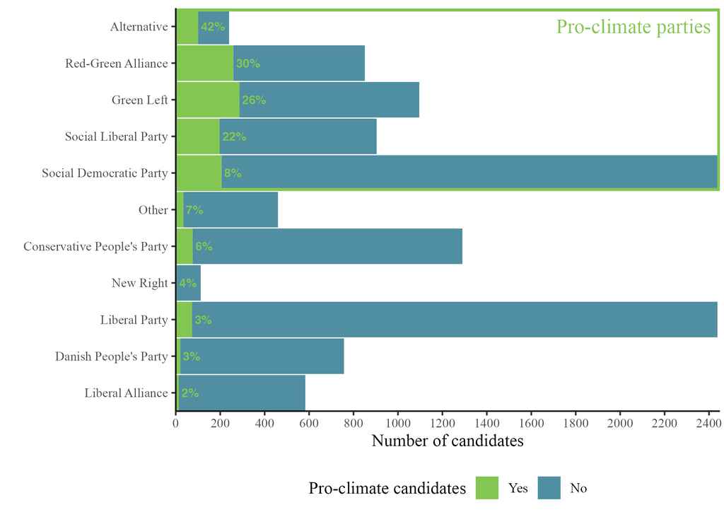

Partiernes klimavenlige kandidater i procent. N = 11,175 kandidater

- **Kunne man have gjort det med manuel kodning? Hvordan?**
- **Kunne man have gjort det med en mere sofistikeret (modelbaseret) tilgang? Ja!**

# Evaluering

Gå til https://evaluering.ku.dk og *brug 5 minutter* på at evaluere **Metode 1**

[figure not shown]

# Text-as-data og big data

## Text-as-data

Kodestrategier (MIS Tabel 21.1)

| Strategi | Operationalisering | Kodning |
| --- | --- | --- |
| Manuel | Manuel | Manuel |
| Automatisk (ordbog) | Manuel | Automatisk |
| Automatisk (superviseret model) | Manuel | Automatisk |
| Automatisk (usuperviseret model) | Automatisk | Automatisk |

- Med kodestrategi #3 og #4 bevæger vi os uundgåeligt over i emnet ‘**text-as-data**’
  - nogen vil også sige med #2
- Vi glider også ligeså stille over i ‘**big data**’

## Text-as-data

- **Naturligt sprog** er en enorm, politisk signifikant datakilde
  - kræver *digitalisering*, *computerkraft* og sofistikerede modeller
  - bl.a. derfor et nyere indslag i statskundskabens metoder
- **“Text as Text versus Text as Data”** (Benoit, 2020)
  - “the study of text that does not **extract elements of the text into a systematic form** – into data – is not treating the text as data.”
  - **tekstdata**: “text that has undergone **selection** and **refinement** for the *purpose of more analysis*”

## Text-as-data – *i R*

- {tidyverse} – *readr*, *dplyr*, *tidyr*, *stringr*
- {tidytext} → https://www.tidytextmining.com/tidytext
- {quanteda} → https://quanteda.io/
- {TM}
- specialiserede pakker til *analyse/modellering*
  - {quanteda.textmodels}
  - {topicmodels}
  - etc. etc.

## Text-as-data – *preprocessing*

1. Skabelse af **tekstkorpus**
   1. valg (indsamling) af tekster
   2. segmentering af tekster (afsnit, kapitler, artikler, sider, sætninger)
2. **Tokenisering**
   1. tokens ofte *ord* (evt. bigrammer – to ord)
   2. fjernelse af tegnsætning, tal, mv.
   3. fjernelse af *stopord* (hyppigt anvendte ord)
   4. *stemming* eller *lemmatisering* (forkort ord til ordstammen)
   5. kollokation (sammenfletning af ord (navne), der ofte hører sammen, fx “Dansk Folkeparti”)
   6. lower case (kun små bogstaver)

## Text-as-data – *preprocessing*

3. **Document-term-matrice** (DTM)
   1. kaldes også, mere generelt, document-feature-matrice (DFM)
   2. (gigantisk) matrice med en række per dokument (tekst) og en kolonne per term (ord)
   3. celler: frekvens, 0/1 tilstedeværelse eller lign.
   4. trimming: “trim” matricen ved at fjerne hyppigst og sjældnest anvendte ord (dårlig evne til at forklare/diskriminere)
4. *Automatisk kodning*, **tekstmodeller** og maskinlæring
   - tager ofte en – renset, *preprocessed* – **DTM/DFM** som input

## Text-as-data – tekstmodeller

- **Scaling**
  - *identifikation af og placering på en latent numerisk dimension*
  - Wordscores (superviseret)
  - Wordfish (usuperviseret) – **eksempel → …**
  - mange flere
- **Klassifikation**
  - *inddeling i kategorier*
  - Naïve Bayes (superviseret)
  - Logistisk regression (superviseret)
  - Topic models: fx *LDA* (usuperviseret) – **eksempel → …**
  - Word embeddings (usuperviseret)
  - mange flere

## Text-as-data – antagelser

- Varierer meget fra model til model, men de er *generelt ret dumme og urealistiske*
- En vigtig (dum) antagelse, som går igen i flere tilgange:
- **“Bag of words”**
  - enhver tekst er bare en **sækfuld ord**
  - ordene, deres frekvens mv. bærer på en betydning
  - men forholdet mellem ordene er ligegyldig (RIP sætninger osv.)
  - fx “Det er IKKE dumt” == “Det er dumt, ikke?”

[figure not shown]

## LDA (Latent Dirichlet allocation)

**Kode**

```r
library(tidytext)
library(topicmodels)
library(quanteda)

# indlæs data: DR sportsnyheder 2015-2019
sport <- read_rds("Data/sporten_sample.rds") |>
  distinct(year = year(dato), titel, .keep_all = TRUE) |>
  select(-year)

# split i et artikel-ord per række
sport_ord <- sport  |>
  unnest_tokens(ord, tekst, to_lower = TRUE) |>
  group_by(ord) |>
  mutate(ord_n = n()) |>
  ungroup()

# trim document-term data frame (langt format)
sport_ord_trim <- sport_ord |>
  filter(
  # fjern 5% mest og mindst anvendte ord
    ord_n < quantile(sport_ord$ord_n, probs = .95) & ord_n > quantile(sport_ord$ord_n, probs = .05),
    # fjern ord på 3 eller færre karakterer
    nchar(ord) > 3,
    # fjern stopord
    !ord %in% quanteda::stopwords("da"))

# opsummer document-word counts
ord_n <- sport_ord_trim |>
  count(titel, dato, ord, sort = TRUE)

# df -> DocumentTermMatrix (DTM): 2979 documents, 9276 terms
dtm <- ord_n |>
  cast_dtm(titel, ord, n)

# kør LDA model med 5 topics
sport_lda <- LDA(dtm, k = 5, control = list(seed = 1234))

# gem model
write_rds(sport_lda, "Data/sport_lda.rds")
```

## Oprindelige data

**Kode**

```r
sport <- read_rds("Data/sporten_sample.rds") |>
  distinct(year = year(dato), titel, .keep_all = TRUE) |>
  select(-year)

set.seed(1234)
sport |>
  sample_n(5) |>
  kable() |>
  kable_styling(font_size = 13)
```

| dato | emne | titel | tekst |
| --- | --- | --- | --- |
| 2017-05-02 | atletik | Kipketer om mulig sletning af rekorder: Det er en fornærmelse | Den danske 800 meter-løber Wilson Kipketer er rystet over, at han nu risikerer at miste sin europarekord fra 1997. Et forslag fra Det Europæiske Atletikforbund (EAA) har fået atletik-verdenen i kog. F… |
| 2016-09-22 | fodbold | VIDEO Skarpe Lyngby spænder ben for Brøndby | Brøndby mistede et skridt i topstriden med et 0-1-nederlag til Lyngby. Jeppe Kjær blev matchvinder for Lyngby. For anden kamp i træk gik Brøndby fra banen uden point i Superligaen. Lyngby løb i et int… |
| 2020-06-01 | sporten | Hobro punkterer spænding om top-6 med sejr over Randers | Med 1-0 i lokalopgøret mod Randers FC vandt Hobro mandag sin første superligakamp siden september. Hobro smagte mandag sejrens sødme for første gang i Superligaen siden 15. september 2019. Hobro vandt… |
| 2020-07-30 | sporten | Tomme tribuner, halsgreb og pokaldebutanter: Men hvad husker vi 2019-2020-sæsonen for? | DR Sportens fodboldkommentator Andreas Kraul giver ti bud på de mest mindeværdige episoder i den forgangne sæson. Coronaen har sat sine spor, og det fik sæsonen i de bedste danske fodboldrækker også a… |
| 2016-07-27 | golf | Sydkoreaner slår McIlroy i drive-konkurrence | Rory McIlroy måtte tage til takke med andenplads efter sydkoreanske An Byeong-Hun i dyst om det længste drive. Den sydkoreanske golfspiller An Byeong-Hun slår længst af alle ved denne uges golfmajor P… |

## (Mest sandsynlige) emner i artiklerne

**Kode**

```r
library(tidytext)
library(topicmodels)
library(quanteda)

# hent model
sport_lda <- read_rds("../Data/sport_lda.rds")

# artikler og forudsagte emner -- kun det mest sandsynlige emne for hver artikel
sport_emner_artikler <- tidy(sport_lda, matrix = "gamma") |>
  group_by(document) |>
  slice_max(order_by = gamma, n = 1) |>
  ungroup() |>
  left_join(select(sport, titel, emne), join_by(document == titel))

# vis artikler og forudsagte emner -- de 5 bedste fit per emne
print_df <- sport_emner_artikler |>
  group_by(topic) |>
  slice_max(order_by = gamma, n = 5) |>
  arrange(topic, desc(gamma)) |>
  ungroup()

print_df |>
  select(-emne) |>
  kable(digits = 3) |>
  kable_styling(font_size = 13)
```

| document | topic | gamma |
| --- | --- | --- |
| Rafael Nadal taber maratondyst og må kigge langt efter Federers rekord | 1 | 0.999 |
| Løchte slider sig til sejr efter tre sæt og er videre i French Open | 1 | 0.999 |
| Ung amerikaner stryger til tops ved Australian Open | 1 | 0.999 |
| Wozniacki tabte igen-igen til Venus Williams | 1 | 0.999 |
| Mourinho før sin debut: 'Jeg kommer ikke til at lave samme fejl' | 1 | 0.999 |
| Alverdens medier citerer rapport om racistisk kommentator-slagside. Tre forskere er ikke overbeviste | 2 | 1.000 |
| Målet er at spille Superligaen færdig: 'Vi arbejder ud fra tre scenarier' | 2 | 1.000 |
| Dansk Svømmeunion modsiger 23 svømmeres kritik af offentlige vejninger: ”Retningslinjerne er blevet fulgt” | 2 | 0.999 |
| Hvem betaler? Det 'økonomiske slagsmål' om gigantisk OL-regning fortsætter | 2 | 0.999 |
| OVERBLIK Doping-skandale i russisk atletik | 2 | 0.999 |
| Delaney og Dortmund sejrer før Bundesliga-brag | 3 | 1.000 |
| Aalborg stikker af i toppen: Mestrene vinder intenst topbrag mod TTH | 3 | 0.999 |
| FCK kæmper sig til smal sejr over Ajax | 3 | 0.999 |
| Indskiftet Brøndby-darling blev helten i hård genstart | 3 | 0.999 |
| GOG er ude af Champions League efter kæmpe kollaps | 3 | 0.999 |
| 398 dage på sidelinjen, én måned på banen og nu: Isolation | 4 | 0.999 |
| KROGHS POWER RANKING Tror på dansk guld, men tre spillere skal ramme topniveau | 4 | 0.999 |
| Klavs Bruun Jørgensens EM-kanin er mor: ’Det har gjort mig bedre på banen’ | 4 | 0.999 |
| Verdensstjerner og holdkammerater: Hansen og Sagosen brager sammen i gruppefinale | 4 | 0.999 |
| VIDEO Efter 12 år med nederlag: Kvindelandsholdet vil slå Holland | 4 | 0.999 |
| Fallesens favoritter: Den tasmanske djævel er førsteudfordreren til Contador | 5 | 0.999 |
| Dansk sejr under seksdagesløbet i Ballerup | 5 | 0.999 |
| ETAPEN PÅ 1 MINUT Belgier fighter sig til forrygende etapesejr | 5 | 0.999 |
| Fuglsang viser Tour-form: Vinder stort fransk etapeløb | 5 | 0.999 |
| Flot etapesejr er blot et kapitel i historisk sæson: Se alle Fuglsangs eminente resultater i 2019 | 5 | 0.999 |

## (Mest sandsynlige) emner i artiklerne

**Kode**

```r
# vis artikler og forudsagte emner -- de 5 bedste fit per emne
print_df |>
  kable(digits = 3) |>
  kable_styling(font_size = 13)
```

| document | topic | gamma | emne |
| --- | --- | --- | --- |
| Rafael Nadal taber maratondyst og må kigge langt efter Federers rekord | 1 | 0.999 | sporten |
| Løchte slider sig til sejr efter tre sæt og er videre i French Open | 1 | 0.999 | tennis |
| Ung amerikaner stryger til tops ved Australian Open | 1 | 0.999 | sporten |
| Wozniacki tabte igen-igen til Venus Williams | 1 | 0.999 | oevrig_sport |
| Mourinho før sin debut: 'Jeg kommer ikke til at lave samme fejl' | 1 | 0.999 | fodbold |
| Alverdens medier citerer rapport om racistisk kommentator-slagside. Tre forskere er ikke overbeviste | 2 | 1.000 | sporten |
| Målet er at spille Superligaen færdig: 'Vi arbejder ud fra tre scenarier' | 2 | 1.000 | fodbold |
| Dansk Svømmeunion modsiger 23 svømmeres kritik af offentlige vejninger: ”Retningslinjerne er blevet fulgt” | 2 | 0.999 | svoemning |
| Hvem betaler? Det 'økonomiske slagsmål' om gigantisk OL-regning fortsætter | 2 | 0.999 | sporten |
| OVERBLIK Doping-skandale i russisk atletik | 2 | 0.999 | atletik |
| Delaney og Dortmund sejrer før Bundesliga-brag | 3 | 1.000 | sporten |
| Aalborg stikker af i toppen: Mestrene vinder intenst topbrag mod TTH | 3 | 0.999 | sporten |
| FCK kæmper sig til smal sejr over Ajax | 3 | 0.999 | fodbold |
| Indskiftet Brøndby-darling blev helten i hård genstart | 3 | 0.999 | sporten |
| GOG er ude af Champions League efter kæmpe kollaps | 3 | 0.999 | haandbold |
| 398 dage på sidelinjen, én måned på banen og nu: Isolation | 4 | 0.999 | sporten |
| KROGHS POWER RANKING Tror på dansk guld, men tre spillere skal ramme topniveau | 4 | 0.999 | haandbold |
| Klavs Bruun Jørgensens EM-kanin er mor: ’Det har gjort mig bedre på banen’ | 4 | 0.999 | haandbold |
| Verdensstjerner og holdkammerater: Hansen og Sagosen brager sammen i gruppefinale | 4 | 0.999 | haandbold |
| VIDEO Efter 12 år med nederlag: Kvindelandsholdet vil slå Holland | 4 | 0.999 | fodbold |
| Fallesens favoritter: Den tasmanske djævel er førsteudfordreren til Contador | 5 | 0.999 | cykling |
| Dansk sejr under seksdagesløbet i Ballerup | 5 | 0.999 | cykling |
| ETAPEN PÅ 1 MINUT Belgier fighter sig til forrygende etapesejr | 5 | 0.999 | cykling |
| Fuglsang viser Tour-form: Vinder stort fransk etapeløb | 5 | 0.999 | cykling |
| Flot etapesejr er blot et kapitel i historisk sæson: Se alle Fuglsangs eminente resultater i 2019 | 5 | 0.999 | cykling |

## (Mest sandsynlige) ord i emnerne

**Kode**

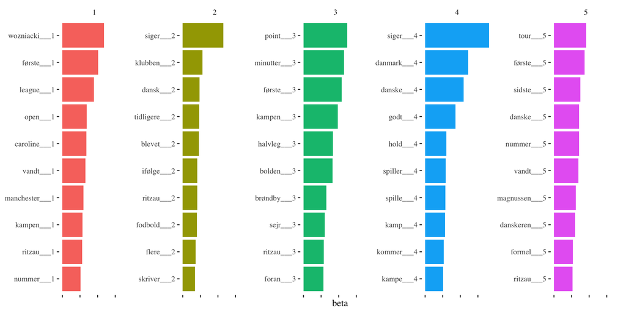

```r
# ord
sport_emner_ord <- tidy(sport_lda, matrix = "beta") |>
  group_by(topic) |>
  slice_max(order_by = beta, n = 10) |>
  arrange(topic, desc(beta)) |>
  ungroup()

sport_emner_ord |>
  ggplot() +
  aes(x = reorder_within(term, by = beta, within = topic), y = beta, fill = factor(topic)) +
  geom_col() +
  facet_wrap(~ topic, scales = "free_y", ncol = 5) +
  coord_flip() +
  guides(fill = "none") +
  ggthemes::theme_tufte() +
  theme(axis.text.x = element_blank(),
        axis.title.y = element_blank())
```

## Wordfish

**Kode**

```r
library(tidytext)
library(quanteda)
library(quanteda.textmodels)
library(quanteda.textplots)
set.seed(1234)

sport <- read_rds("Data/sporten_sample.rds") |>
  filter(emne == "fodbold") |>
  sample_n(40)

# split into words
sport_tokens <- sport  |>
  distinct(titel, .keep_all = TRUE) |>
  corpus(docid_field = "titel", text_field = "tekst") |>
  tokens(remove_punct = TRUE) |>
  tokens_select(pattern = stopwords("da"), selection = "remove")

dfm <- dfm(sport_tokens) |>
  # ord bruges min. 2 gange i min. 2 dokumenter
  dfm_trim(min_termfreq = 2, min_docfreq = 2, verbose = TRUE)

sport_wf <- textmodel_wordfish(dfm)

# gem model
write_rds(sport_wf, "Data/sport_wf.rds")
```

## Wordfish – resultat

**Kode**

```r
library(tidytext)
library(quanteda)
library(quanteda.textmodels)
library(quanteda.textplots)

# indlæs model
sport_wf <- read_rds("Data/sport_wf.rds")

# plot
textplot_scale1d(sport_wf)
```

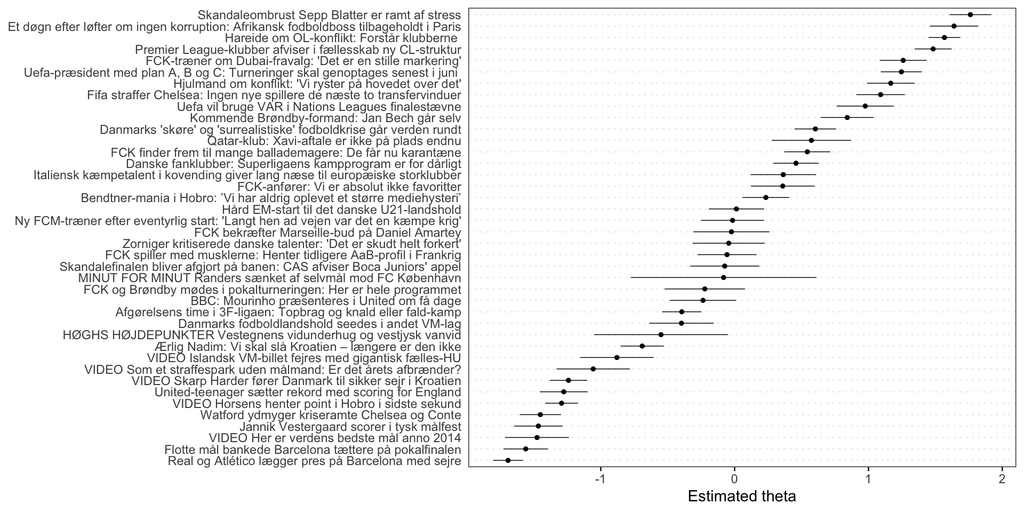

## Superviserede tekstmodeller

- De to eksempler (LDA og Wordfish) var begge *usuperviserede*
  - nemt at kaste sig over, sjovt, interessant
  - men også stor chance for at resultaterne ikke giver meget mening, jf. valideringen (meget støj, lav præcision)
- Bedre kontrol med de superviserede modeller
  - ofte bedre resultater (mere manuelt arbejde)
  - essensen i superviserede tekstmodeller er, at man giver modellen “facit” i form af nogle kategoriserede eksempler
  - en (tilfældig) del af datasættet, som man (fx) håndkoder (*træningssættet*), før modellen ‘trænes’
  - validerer/tester derefter på *testsættet*

## Kvantitativ indholdsanalyse – opsummering

- **Fire typer af kodningsstrategier**
  - deler samme mål (nye, strukturerede data)
  - kræver forskellige ting af os
  - har distinkte fordele og ulemper
- *Manuel* og *automatisk (ordbog)* er lige til at gå igang med
  - operationalisering, kodning og validering tager tid (varierer)
- De (andre) *automatiske* kræver lidt mere forberedelse og *R-skills* (præprocessering og validering)
  - kan potentielt give bedre, mere dybdegående resultater – identificere mønstre, vi ikke selv kan se
  - mindre transparens, højere reliabilitet, mere efficient ved stort N
- Stort tematisk overlap med **text-as-data**

# Big data

## Big data

- Hvad er ‘big data’?
  - *omfang*, *variation*, *hastighed* (Laney 2001)
  - en slags *biprodukt* fra det højteknologiske senmoderne samfund
  - ikke skabt/indsamlet for vores skyld
  - ofte ustruktureret og/eller uigennemskueligt
  - drevet af internettet, apps, smart-devices, nye teknologier
  - og af *digitaliseringen* af den offentlige sektor

## Mange fællestræk med kvantitativ indholdsanalyse

- Det bærer *pensum* også præg af
- Begge handler om at *anskaffe og strukturere* data
- Gøre det klar til *analyse* (banal eller avanceret)
- **‘Big data’** lægger mere vægt på:
  1. original **dataindsamling** (typisk fra *internettet*)
  2. avancerede statistiske modeller, herunder **maskinglæring**
- Relativt nyt område – stort inden for *social data science*
- Stor plads til nysgerrighed og kreativitet i hele processen
  - færre konventioner og regler, end vi er vant til

## Adgang til data

- Ofte begrænset
  - sociale medier
  - andre kommercielle virksomheder
  - sommetider også myndigheder, organisationer (persondatabeskyttelse eller andre interesser)
- Men internettet er fyldt med data
  - man kan nærmest sige, at internettet ER data
- Udover *offentligt tilgængelige datasæt*, og datasæt vi får adgang til ved at *henvende os direkte*:
  - **(web)scraping**
  - **APIer**
- OBS! Etik og jura

## Adgang til data: scraping og APIer

- **(Web)scraping**:
  - alle hjemmesider kan uden videre downloades
  - informationen på hjemmesiden er ofte struktureret
  - vi kan bruge online-værktøjer (https://selectorgadget.com/) og hjemmesidens *rå HTML-kode* til at gennemskue strukturen
  - med {rvest}-pakken kan vi downloade (dele af) hjemmesider direkte i R
  - her kan vi samle informationen, fx i en *data.frame*
  - hvis mange hjemmesider har samme struktur, kan vi gentage lynhurtigt, igen og igen
  - eksempel: DR-artikler

## Adgang til data: scraping og APIer

- **APIer:**
  - *Application Programming Interface*
  - mange større virksomheder, organisationer og myndigheder tilbyder data gennem en API
  - man skal ofte oprette sig som bruger (bl.a. så de kan monitorere ens brug af data)
  - gennem **APIen** kan man hente data fra en bestemt database
    - typisk med en række specifikationer/kriterier
  - i praksis ofte blot en lang **URL-adresse** med en specificering af ‘data-søgningen’ og ens login-info (autentifikation)
  - resultatet kan hentes direkte ind i R med {httr} og renses/samles/forberedes til analyse dér

## Databehandling

- Med ‘big data’ handler databehandlingen (*kodningen*) ofte om *dimensionalitetsreduktion*
  - der er ofte ekstremt mange, vidt forskellige variable eller *features*  
    (dimensioner i data)
  - man skal ofte holde tungen lige i munden for at bevare fokus og overblik
  - databehandling indebærer at ud-/fravælge data og opsummere data i færre variable (underliggende/tværgående mønstre)
- Det er vigtigt at sætte sig ind i, hvordan data er skabt
  - samme logik som med en *kodebog*
  - vi er nødt til at sætte os ind i dokumentationen bag APIen og sikre os, at vi forstår hjemmesidens kontekst og struktur

## Maskinlæring

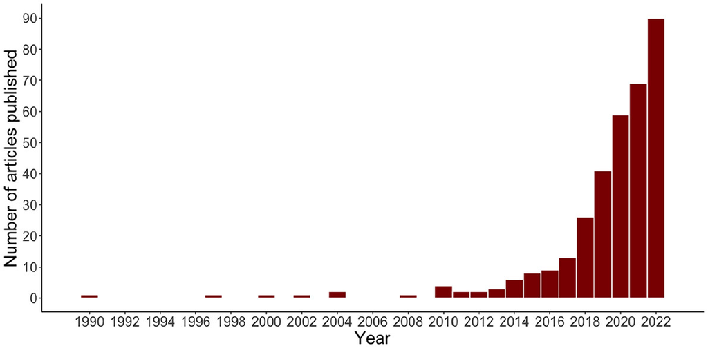

Forskningsartikler i Statskundskab, der anvender maskinlæring (n=339). Kilde: de Slegte et al. (2024)

- 68 % text-as-data, 2 % billeder, 29 % traditionelle datasæt

## Maskinlæring

- Handler om at træne en – superviseret eller usuperviseret – statistisk model til bedst muligt at forudsige noget
  - i sin essens ikke meget anderledes end at lave en **lineær regressionsmodel** mhp. *prediktion*
  - blot mere avancerede modeller, ofte specialiseret til fx tekstdata
- Som regel opdeler man data i et **træningssæt** og et **testsæt**
  - på *træningssættet* optimeres modellens evne til at *forudsige/klassificere/xx*
  - derefter tester man samme model på helt nye data → *testsættet*
  - det gør man for at undgå **overfitting**
    - → man vil have en god model, der ikke blot (over)forklarer den konkrete stikprøve, men også er god til andre/fremtidige data
- Avancerede maskinlæringsmodeller har også et trade-off mellem *recall* og *præcision*

## Eksempel: ‘Measuring Elite Personality Using Speech’

- Ramey et al. (2016)
- Anvender en (prætrænet) maskinlæringsmodel til at forudsige *fem personlighedstræk* for medlemmer af Kongressen (1996-2014)
  - ‘Big Five’: åbenhed, venlighed, samvittighedsfuldhed, udadvendthed, følelsesmæssig stabilitet
- Baseret på deres taler i Kongressen
- Muliggør sammenligning over tid og mellem medlemmer
  - præsenterer en række analyser
  - kan bruges i andre analyser

## Eksempel: ‘Measuring Elite Personality Using Speech’

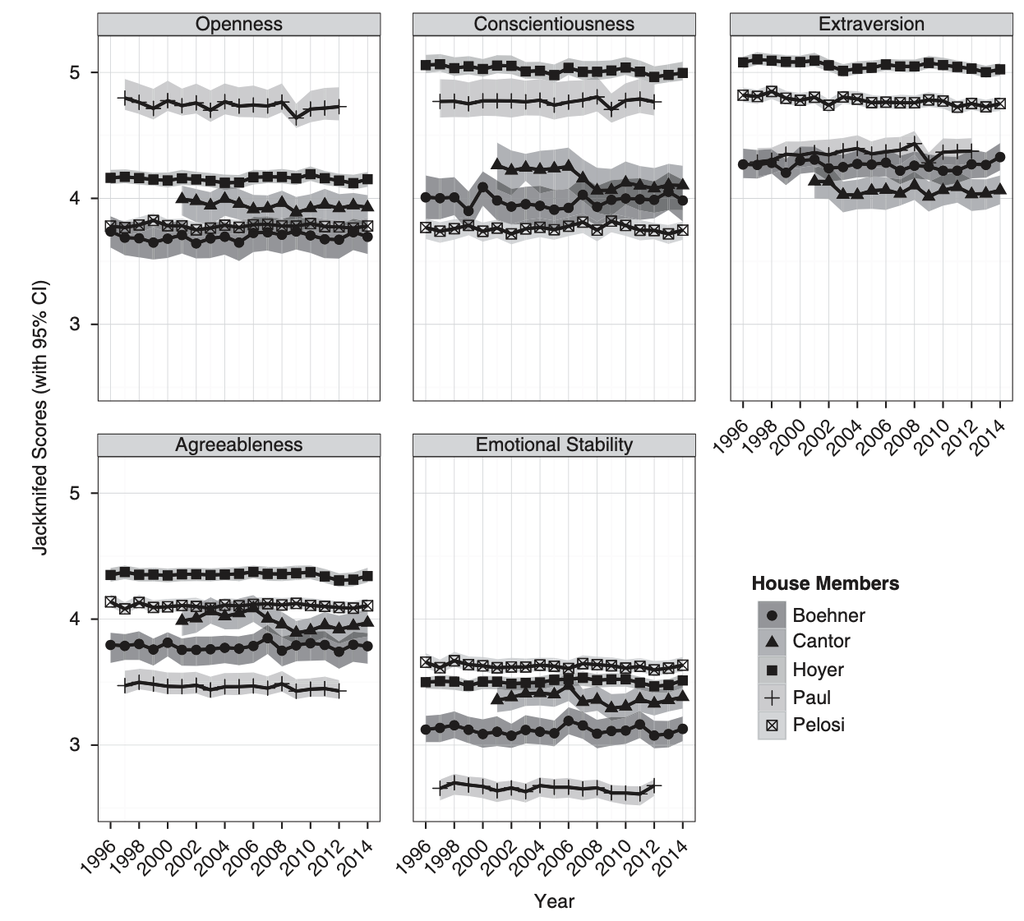

Forudsagte personlighedstræk for 5 Kongressmedlemmer. Kilde: Ramey et al. (2016)

## Sammenhæng med ideologi

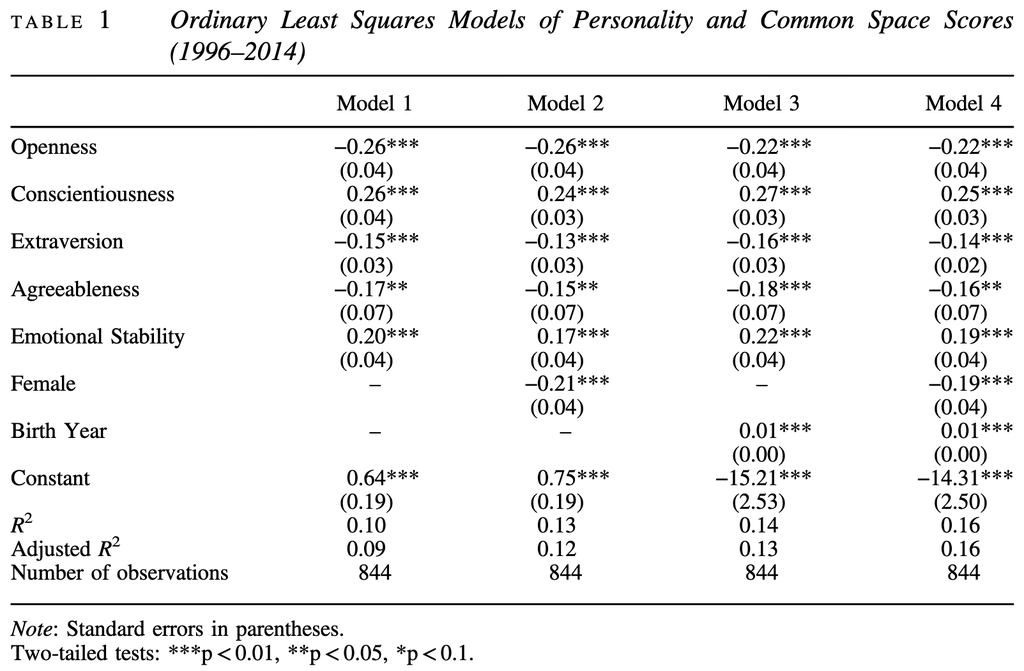

OLS-regression af sammenhæng mellem ideologi og personlighedstræk. Kilde: Ramey et al. (2016)

## Fordele/ulemper ved big data

- Nye datakilder (big data) i statskundskaben er enormt spændende, inspirerende og har stort potentiale
  - stor plads til kreativitet
- Men både *velkendte* problemer:
  - **sampling bias** (eksempel: *Twitter/X*-data)
- Og *nye* problemer:
  - fx *algoritmisk confounding* (eksempel: *Google Flu Trends*)
  - ‘levende’ data → feedbackloop hvor nye data påvirkes af eksisterende data
- Mange ubekendte i forhold til *generaliserbarhed*, validitet, reliabilitet mv.
  - afhænger af konkret metode/model/data/kontekst
- Godt råd: gør dig fortrolig med data
  - vær bevidst om, *hvordan data skabes* (og filtreres/modificeres) + *konteksten*

## Opsummering

- **Kvantitativ indholdsanalyse** handler om at skabe struktur i et råt datamateriale
  - kodning af datamaterialet (ofte tekster) på centrale dimensioner
  - primært en metode til dataskabelse/**måling** → *analysen* kommer i anden række
- **Fire typer:** (1) manuel, (2) automatisk (ordbog), (3) automatisk (superviseret) og (4) automatisk (usuperviseret)
  - samme mål: *at skabe et systematisk datagrundlag ved at **kode** materialet*
  - fordele/ulemper, muligheder/begrænsninger, styrker/svagheder ved hver tilgang
- **Tre trin:** *operationalisering*, *kodning* og *validering* (evt. også tekst-*preprocessing*)
- **Text-as-data:** samlebetegnelse for computerbaseret behandling af ‘naturlig tekst’ og *automatiserede tilgange til kvantitativ tekstanalyse*
- **Big data:** samlebetegnelse for nye digitale *datakilder* og *sofistikerede modeller* til databehandling, kodning og analyse

## Næste uge

- Sidste undervisningsuge
- Forelæser: *Kasper Møller Hansen*
- Metodiske kombinationer
- Formidling af resultater
- Opsamling

### Tusind tak for denne gang 😊